# FINANCIAL FRAUD THROUGHOUT HISTORY: A FORENSIC APPROACH - Jim Chanos

## **5 Models of Corporate Fraud**

1. Kindleberger/Minsky;  
2. The “Fraud Triangle;  
3. Black’s “control fraud;

1. McLean’s “legal fraud
2. Jennings’s “seven signs of ethical collapse

## **Learning Objectives:**

> 1. How does a study of historical fraud provide a framework for detecting future financial frauds?)
> 2. Review and analyze the red flags alerting investors to financial deception and fraud, using the Schilit/Perler templates. (What are the earnings, cash flow, and metrics signals?)
> 3. Apply a range of forensic tools to financial reporting documents to determine the tools’ validity and limitations for different frauds. (Why do auditors miss the obvious?)
> 4. Develop an analytical framework to single out relevant data – including what internal whistleblowers and journalists provide – for building a case for fraud well before market regulators uncover wrongdoing. (What data matter most and why?).
> 5. Review and analyze government reactions (i.e., regulatory initiatives, approaches to prosecution) to financial fraud, assessing the responses, the motivations driving the actions, and the impact (any change in incidences of fraud; “lessons learned”). (Why wasn’t one major executive – the “untouchables” as PBS Frontline put it ─ sent to jail for their role in frauds contributing to the 2007-2008 financial crisis?)

## Recommended Tectbooks

1. Howard Schilit and Jeremy Perler, Financial Shenanigans: How to Detect Accounting Gimmicks and Fraud in Financial Reports. Third Edition. New York: McGraw-Hill, 2010.
2. Ed Chancellor, Devil Take the Hindmost. New York: Plume, 2000.

# **Module 1. OVERVIEW: The Models and Cues of Deceits**

**Course Overview** :

> What is financial fraud? How is it defined legally? What are the difficulties involved in proving whether fraud exists? Is “*willful blindness*” a strong tool for prosecutors? Where can the line be drawn between “*aggressive accounting*” and fraud? What are the forces driving the deceptions? Rapid asset growth, erratic increases in revenues dependent on unsustainable growth, discrepancies between financial and nonfinancial performance, and stealth expenses are all red flags. Are there other cues of deceit such as signs of a collapse in ethics? Which ones do investors and auditors typically miss, and why? What roles have whistleblowers, journalists, and investors played in detecting fraud? How accurate is the “madness” or the “wisdom” of the crowds? Today, is fraud harder to uncover given the complexity of accurately valuing and reporting on highly sophisticated financial instruments and intangibles? Do corporations’ multinational Brogdingnagian structures make it easy to hide fraud? What forensic tools are effective? (In subsequent lectures, the tools will be applied to various cases.) Are number theories such as Benford’s Law useful? What nonfinancial signs, such as a company’s public persona or examples of ethical collapse, signal deeper problems? (“No one will find me to have knowingly committed fraud,” said Bernard Ebbers, the WorldCom CEO who was eventually convicted in 2005 of fraud and conspiracy as a result of his company’s false financial reporting.)"

## Model 1. Kindleberger/Minsky

### Seven stages unfold in a speculative bubble:

1. displacement (an event that sharply changes expectations);
2. expansion;
3. euphoria;
4. distress;
5. revulsion;
6. crisis; and
7. contagion.

### Types of Bubble -

1. Prices rise rapidly and then it crashes from the speculative peak level.

   The general argument is that speculative bubbles are **self-fulfilling prophecies**. Price rises because agents expect it to do so, with this ongoing expectation providing the increasing demand that keeps the price rising. If due to some exogenous shock the price stops rising, this breaks the expectation, and the speculative demand suddenly disappears, sending the price back to its fundamental (or thereabouts) very rapidly where there is no expectation of the price rising.
2. Price rises, reaches a peak that may last for a while, and then declines again, sometimes at about the same rate as it went up.

   There is no crash as such, in contrast with other types of bubbles in which there is a period when the price declines much more rapidly than it ever rose, often characterized by panic among agents as described by both Minsky and Kindleberger.
1. The third type of bubble is that which exhibits a period of financial distress, a type first identified and labeled by Minsky (1972).

   This the price rises to a peak that is followed initially by a gradual decline for a while, but then there is a panic and crash. What is involved is heterogeneous behavior by agents, with some insiders getting out at the peak while others hang on during the period of financial distress until the panic and crash.This is most common in history.

The anatomy of structure is borrowed from - https://www.variantperception.com/2017/09/22/the-anatomy-of-a-bubble/

##### Displacement

> Bubbles start with a displacement, some sort of a shock to the system. A displacement could be a major political change, deregulation, a technological innovation, a financial innovation or a shift in monetary policy. The >displacement creates a new opportunity in at least one sector of the economy. One example is the widespread adoption of computers, the internet and email in the US in the 1990s, which set the stage for the dot-com bubble.

##### Expansion

> A boom begins, especially in the favored sector, as optimism grows. There is a positive feedback loop as the price of stocks, one or more commodities, and/ or real estate increase, which then leads to greater consumption and >investment, which leads to greater economic growth. Credit fuels the boom. Borrowers become more willing to take on debt and lenders are increasingly willing to make riskier loans as economic prospects improve. This expansion of credit isn’t necessarily provided by banks. The Tulip Mania in 1636 in Holland, for example, was fueled by vendor-financing from bulb sellers. However, banks have been the predominant source of credit since the 19th century. Banks can expand credit further and more rapidly than vendors could. To make matters worse, new banks are often formed in the expanding economy. This causes banks to further loosen their credit standards to avoid losing market share.

##### Euphoria

> A boom transforms into euphoria as “rational exuberance morphs into irrational exuberance.” There are hundreds of books documenting the endless possibilities of the economy (e.g. Japan and The East Asian Miracle in Japan in the 1980s, and Dow 40,000 in 1999). Participants extrapolate recent price increases into the future, expecting prices to continue to increase at unsustainable rates. Some, especially industry insiders, realize that there is a bubble, but many continue to participate in the market, believing they can sell to “the greater fool” before the implosion. However, more and more euphoric outsiders begin to enter the market as media attention grows and individuals see others getting rich. As Kindleberger quoted in Manias, Panics and Crashes, “there is nothing as disturbing to one’s well-being and judgment as to see a friend get rich.” The rush of capital causes a further increase in prices, and sound investment shifts to wild speculation. Individuals invest with the hope of short-term capital gains, and debt compounds as people borrow or trade on margin to further speculate. Money seems free. Fraud is also common at this stage, although it typically is not exposed until later.

##### Distress

> At some point, an event hits that causes a decline in confidence and a pause in the explosive price increase. The event could be a bankruptcy, a change in government policy, a piece of news (real or rumored), or a flow of funds from the country. The response to these events differs in bubbles because of the debt build-up. People who financed their purchases with borrowed money become distressed sellers as the income on their assets drops below their interest payments. Kindleberger noted, “The economic situation in a country after several years of bubble-like behavior resembles that of a young person on a bicycle; the rider needs to maintain forward momentum or the bike becomes unstable.” A slowing bike is actually a better metaphor than a bubble. Sometimes panic sets in immediately, but in other cases it can take up to several years for the crisis to fully develop. In the dot-com crisis, panic happened almost immediately, while it took a few months for panic to set in during the Great Financial Crisis.

##### Panic

> Not everyone realizes that a crisis is unfolding at the same time. Insiders and institutional investors usually sell first. Once other market participants realize the gravity of the situation (perhaps after another major event), run-of-the-mill selling turns into outright panic as everyone tries to get out at the same time. Prices plummet and levered companies increasingly go bankrupt as they can’t meet their interest payments. The sell-off typically spreads to other sectors and other countries. As bankruptcies mount, banks can begin to fail, further drying up credit when it’s needed the most. The panic continues until a lender of last resort convinces investors that cash will be made available to meet demand, or prices fall so low that value investors start to buy back in.

top

## Model 2. The Fraud Triangle

Fraud Triangle (a micro-model): Fraud detection requires understanding the psychology and personal character traits of fraudsters and how they react to opportunities.

Three key factors are present when an ordinary person commits fraud: rationalization, opportunity, and motivation or pressure:

1. Pressure
2. Opportunities
3. Rationalization

#### Pressure

> - The incentive to misstate earnings can arise due to pressure to meet analysts' forecasts, compensation and incentive structures, the need for external financing, or poor performance.
> - Motivation to manipulate earnings is the desire to attract external financing at low cost.
> - Equity Incentives ~ no relation with fraud but the likelihood of a misstated financial statement increases when the CEO has a sizable amount of stock options "in-the-money."
> - They also find that misstatements are more likely for firms constrained by debt covenants, firms raising new debt or equity capital, or firms that have a CEO who serves as the chairman of the board
> - Beneish (1999a) finds that, for a group of firms subject to accounting enforcement actions by the SEC, managers are more likely to sell equity holdings and exercise stock appreciation rights in periods when earnings are inflated, suggesting insider trading behavior may be informative about earnings overstatements.
> - A Glass Lewis & Co. (2006) report states that about half of the companies implicated in backdating their stock options have restated their financial statements
> - Rosner (2003) findings suggest that the behavior of failing firms that do not appear distressed on the basis of accrual data, but nonetheless show significant decreased cash flows, is consistent with material earnings overstatements in non-going-concern years that are followed by overstatement reversals in going-concern years

#### Opportunities

> - Some of risk factors include the nature of the industry or the entity's operations such as significant complex or related party transactions, ineffective monitoring of management, a complex organizational structure such as one that involves several legal entities, and ineffective controls due to a lack of monitoring of controls or circumvention of controls.
> - Do they company have strong internal control systems?
> - Several studies have shown that ineffective monitoring of management in the form of weak corporate governance is associated with a higher likelihood of fraud.
> - Firms manipulating earnings are more likely to have less independent boards, unitary structure for chairman and CEO. More likely to be the founder of the company, less likely to have audit committee and less likely to have outside blockholders.
> - Abbott et al. (2004) address the impact of audit committee characteristics (independence, activity level, and financial expertise) on the likelihood of financial statements being restated (and also fraud).
> - McMullen and Raghunandan (1996) also document that compames with financial reporting problems are less likely to have an audit committee composed of independent directors
> - Smith et al. (2000) examine a model where the strength of internal controls is inversely related to the propensity of a manager to commit fraud. In their model, the auditor's assessment of the control system affects their allocation of effort between control testing and substantive testing, but the likelihood of detecting the fraud does not increase when the auditor exerts effort to assess controls.Smith et al. (2000) examine a model where the strength of internal controls is inversely related to the propensity of a manager to commit fraud. In their model, the auditor's assessment of the control system affects their allocation of effort between control testing and substantive testing, but the likelihood of detecting the fraud does not increase when the auditor exerts effort to assess controls.
> - Bernardi (1994) finds that managers outperform seniors in a fraud detection case when they are exposed to an initial evaluation of client integrity and competence; however, this finding is attributable to managers with a high level of moral development.

#### Rationalizations

> - Accounting standards can contribute to reducing both the opportunity and attitude toward fraudulent financial reporting.
> - Researchers fount that when accounting standards are precise, managers are more likely to attempt earnings management with transaction structuring (such as structuring a lease in a particular way to avoid a capital lease classification or by opportunistically timing sales of available-for-sale securities), and auditors are less likely to adjust those attempts.
> - Managers were more likely to make attempts that decrease income with unstructured transactions (such as increasing or decreasing estimates involving judgment) when standards were imprecise.
> - Managers are more likely to make attempts to increase earnings, but auditors are more likely to require adjustment in those cases, particularly if the amount is material.

### Syptoms of Fraud

Symptoms of fraud can be separated into six main groups:

1. Accounting anomalies,
2. Internal control weaknesses,
3. Analytical anomalies,
4. Extravagant lifestyle,
5. Unusual behavior,
6. Tips and complaints.

#### 1. Accounting Fraud

##### Irregularities in Source Documents:

• Missing documents  
• Stale items on bank reconciliations  
• Excessive voids or credits  
• Common names or addresses of payees or customers  
• Increased past-due accounts  
• Increased reconciling items  
• Alterations on documents  
• Duplicate payments  
• Second endorsements on checks  
• Document sequences that do not make sense  
• Questionable handwriting

#### 2. Internal control weaknesses

• Lack of segregation of duties  
• Lack of physical safeguards  
• Lack of independent checks  
• Lack of proper authorization  
• Lack of proper documents and records  
• Overriding of existing controls  
• Inadequate accounting system

#### 3. Analytical Fraud Symptoms

• Unexplained inventory shortages or adjustments  
• Deviations from specifications  
• Increased scrap  
• Excess purchases  
• Too many debit or credit memos  
• Significant increases or decreases in account balances, ratios, or relationships  
• Physical abnormalities  
• Cash shortages or overages  
• Excessive late charges  
• Unreasonable expenses or reimbursements  
• Excessive turnover of executives  
• Strange financial statement relationships, such as:

```
- > Increased revenues with decreased inventory
- >Increased revenues with decreased receivables
- >Increased revenues with decreased cash flows
- >Increased inventory with decreased payables
- >Increased volume with increased cost per unit
- >Increased volume with decreased scrap
- >Increased inventory with decreased warehousing
costs
```

#### 4. Extravagant Lifestyle

-> Most people who commit fraud are under financial pressure. Sometimes the pressures are real; sometimes they merely represent greed. Once perpetrators meet their financial needs, they usually continue to steal, using the embezzled funds to improve their lifestyles.

#### 5. Unusual Behavior

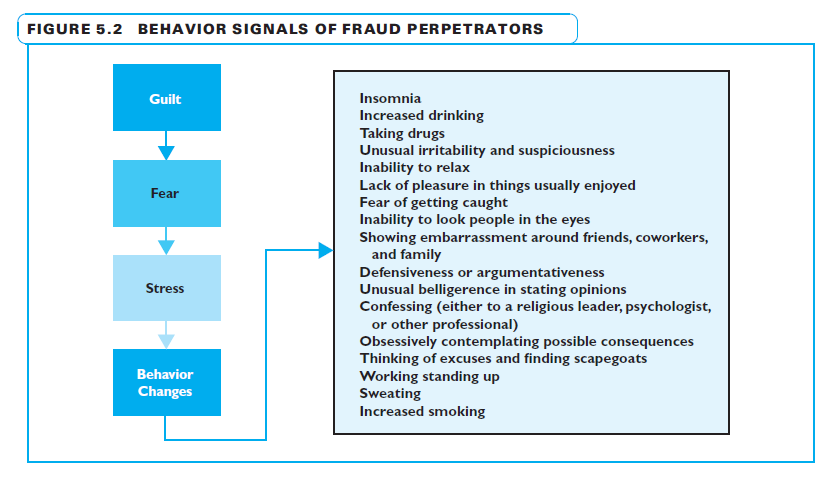

#### 6. Tips and Complaints

-> The types of fraud committed are - Concealment, theft and conversion.

-> Usually Company employees are in the best position to detect fraud.

top

## Model 3. Control Fraud by William Black

> William Black, a former Federal regulator of banks and now a university professor, defines control fraud as using a corporation as both a ”weapon” and a “shield” to conduct fraudulent activity. The CEO can eliminate any checks and balances to facilitate the conduct of fraud (“weapon”) and co-opt auditors to sign off on fraudulent accounting (“shield”).

#### Chapter 1 Notes. The Best Way to Rob a Bank Is to Own One (William Black)

> - The defrauders use companies as both sword and shield. They have shown themselves capable of fooling the most sophisticated market participants and academic experts. They are financial superpredators who use accounting fraud as a weapon and a shield against prosecution.
> - The person who controls a company (or country) can defeat all internal and external controls because he is ultimately in charge of those controls. Fraudulent CEOs do not simply defeat controls; they suborn them and turn them into allies.
> - Top law firms, under the pretense of rendering zealous advocacy to the client, have helped fraudulent CEOs loot and destroy the client.
> - Top-tier audit fi rms are even more valuable allies (Black 1993e). Every S&L control fraud, and all of the major control frauds that have surfaced recently, were able to get clean opinions from them.
> - Control frauds, using accounting fraud as their primary weapon and shield, typically report sensational profi ts, followed by catastrophic failure.
> - These fictitious profi ts provide the means for sophisticated, fraudulent CEOs to use common corporate mechanisms such as stock bonuses to convert firm assets to their personal benefit.
> - In short, they camouflage themselves as legitimate leaders and take advantage of the presumption of regularity (and psychic rewards) that CEOs receive.
> - Control frauds frequently make (directly and indirectly) large political contributions.
> - This generally means investing in assets that have no readily ascertainable market value and arranging reciprocal “sales” of goods, which can transform real losses into fictional profits. It can also mean, however, targeting poorly regulated industries. They can make the fi rm grow rapidly and become a Ponzi scheme.
> - Control frauds have shown the ability to fool the most sophisticated market participants. They can be massively insolvent and still be touted by experts as among the very best firms in the world.
> - Scholars asserted that private market discipline would prevent any excessive risk taking in industries that had no government guarantee. This view was incorrect: S&L control frauds consistently showed the ability to deceive uninsured private creditors and shareholders.
> - The scariest aspect of control frauds, however, is that they can occur in waves, causing systemic damage.
> - Indeed, I write in large part to help build a new economic theory of fraud arising from George Akerlof ’s classic theory of lemons markets (1970) and Henry Pontell’s work on “systems capacity” limitations in regulation that may increase the risk of waves of control fraud (Calavita, Pontell, and Tillman 1997, 136).
> - Control frauds’ key skill is manipulation. Fraudulent CEOs’ ability to manipulate was limited primarily by their audacity and the leadership and moral strength of their opponents.
> - Morals matter, but people are capable of doing immoral acts while believing they are morally superior. It is so hard to accept that a CEO can be a crook and that, because he owns substantial stock in the company, the risk increases that he will engage in control fraud if the firm is failing
> - Successful control frauds have one primary skill: identifying and exploiting human weakness. Audacity is the trait that sets control frauds apart.
> - Control frauds create a “fraud friendly” corporate culture by hiring yes-men. They combine excessive pay, ego strokes (e.g., calling the employees “geniuses”), and terror to get employees who will not cross the CEO. Control frauds are control freaks.
> - The second reason control frauds are so destructive is that the CEO optimizes the firm as a fraud vehicle and can optimize the regulatory environment. The CEO causes the firm to engage in transactions that are ideal for fraud. Control frauds are accounting frauds.
> - A Ponzi must bring in new money continuously to pay off old investors, and the fraudster pockets a percentage of the take. The record “income” that the accounting fraud produces makes it possible for the Ponzi scheme to grow. S&Ls made superb control frauds because deposit insurance permitted even insolvent S&Ls to grow.
> - Control frauds are predators. They spot and attack human and regulatory weaknesses. The CEO moves the company to the best spot for accounting fraud and weak regulation.
> - Political contributions and supportive economic studies secure deregulation. Control frauds use the company’s resources to buy, bully, bamboozle, or bury the regulators.
> - Control frauds are human; they enjoy the psychological rewards of running one of the most “profitable” firms.
> - The control frauds we convicted became too greedy and began to take funds through “straw” borrowers. A prosecutor who detects the straw can win a conviction.

##### How do waves of control fraud endanger the general or regional economy?

> - Individual control frauds should be a central regulatory concern because they cause massive losses.

S&L Fraud and Framework of Systematic Fraud ~

> - S&L assets were long-term (thirty-year), fixed-rate mortgages, but depositors could withdraw their money from the S&L at any time. If interest rates rose sharply, every S&L would be insolvent.
> - Paul Volcker raised rates in 1979.
> - By mid-1982, on a market-value basis, the S&L industry was insolvent by 150 billion.
> - This maximized the incentive to engage in reactive control fraud and made it far cheaper for opportunists to purchase an S&L.
> - These factors ensured that there would be an upsurge in control fraud, but the cover-up of the industry’s mass insolvency (and with it, that of the federal insurance fund), deregulation, and desupervision combined to create the perfect environment for a wave of control frauds.
> - Criminologists call an environment that produces crime “criminogenic.”
> - Control frauds’ investments are concentrated and driven by fraud, not markets.
> - Because the control frauds grew at astonishing rates, this quickly produced a glut of commercial real estate in markets where the control frauds were dominant (Texas and Arizona were the leading examples).
> - Moreover, being Ponzi schemes, they increased their speculative real estate loans even as vacancy rates reached record levels and real estate values collapsed.
> - Systemic risk causes control frauds to occur at the same time. They concentrate in the particular industries that foster the best criminogenic environments. They also concentrate in investments best suited for accounting fraud. That triple concentration means that waves of control fraud will create, infl ate, and extend bubbles.

##### Moral Hazard

> - Moral hazard is the temptation to seek gain by engaging in abusive, destructive behavior, either fraud or excessive risk taking. Failing firms expose their owners to moral hazard.
> - Moral hazard arises when gains and losses are asymmetrical.
> - A company with 100 million in assets and 101 million in liabilities is insolvent. If it is liquidated (sells its assets), the stockholders will get nothing because they are paid only after all the creditors are paid in full. In my example, the assets are not suffi cient to repay the creditors’ claims (liabilities), so liquidation would wipe out the shareholders’ interest in the company.
> - Risk and reward are asymmetric when a corporation is insolvent but left under the control of the shareholders. If the corporation makes an extremely risky investment and it fails, the loss is borne entirely by the creditors.
> - If the investment is a spectacular success, the gain goes overwhelmingly to the shareholders. The shareholders have a perverse incentive to take unduly large risks rather tha to make the most productive investments.

##### Why the S&L industry suffered a wave of control fraud

> - Opportunistic control fraud can also occur in waves. Opportunists seek out the best field for fraud. Four factors are critical: ease of obtaining control, weak regulation, ample accounting abuses, and the ability to grow rapidly.
> - An industry with weak rules against fraud is likely to invite abusive accounting. Industries with abusive accounting have superior opportunities for growth because they produce the kinds of (fi ctitious) profi ts and net worth that cause investors and creditors to provide ever-greater funds to the control fraud.
> - Interest rate risk rendered every S&L insolvent (in market value) in 1979–1982, making it far cheaper and easier for opportunists to get control.
> - Owners and regulators were desperate to sell S&Ls; opportunists were eager to buy. The Bank Board and accountants used absurd “goodwill” accounting to spur sales.
> - The industry will lobby regulators, the administration, and Congress to aid the cover-up by endorsing accounting abuses and minimizing takeovers of insolvents.

##### The cover-up of the insolvency of the industry and the FSLIC

> - Congress wanted a cover-up. Americans loved the S&L industry because S&Ls made loans to people, not corporations, and made possible the American dream (owning a home).
> - Politicians loved S&Ls because Americans did, because S&Ls were large contributors, and because they had the best grassroots lobbyists.
> - Their trade association, the United States League of Savings Institutions (the League), was a force of nature, as were its allies the National Association of Homebuilders (NAHB) and the National Association of Realtors (NAR). (Their PACs traveled in packs.)
> - Despite all these differences, the FDIC adopted phony accounting for savings banks to hide their insolvency and stopped closing them, showing how strong the pressures were for cover-ups in the 1980s.

##### The S&L cover-up optimized the industry for control fraud

> - There are five central facts that explain why the Bank Board’s implementation of the cover-up proved so harmful.
> - First, it came from the top, and it came via consensus.
> - Second, the design and implementation of the cover-up guaranteed a disaster. Moral hazard theory unambiguously predicts that if you greatly weaken restraints on abuse at a time of mass, intense moral hazard, you will suffer severe abuses.
> - Third, no economist contemporaneously predicted that the administration’s policies would produce a disaster. (there were “no Cassandras” among economists).
> - Fourth, although no economist spotted the problems, roughly two hundred opportunistic control frauds promptly spotted the opportunities and rushed to enter the industry.
> - Fifth, the Bank Board lost vital moral capital when it abused accounting practices to cover up the industry’s and the FSLIC’s insolvency. A regulator succeeds largely on the basis of moral suasion.

##### The cover-up led the Reagan administration to oppose Gray’s war on the frauds

> - First, closure of the frauds would reveal the industry’s insolvency just when the Administration was pronouncing it cured.
> - Second, The administration designed, implemented, and praised the deregulation that attracted the control frauds and made them superpredators. Reregulation would have been an admission of guilt.

##### Why did economists and the administration get the debacle so wrong?

> - Economists know almost nothing about fraud. The dominant law-and-economics theory is that there is no serious control fraud, so it is not worth studying. There is no coherent theory of fraud, though there is fi nally some interest in developing one
> - Second, prominent U.S. economists generally believe that regulation is the problem and deregulation is the solution. The deregulators’ ideology was the initial problem, but the fact that their policies led to disaster also brought on acute embarrassment.
> - Third, economists (and the administration) were like generals preparing to fight the last war. In the S&L context, this meant concentrating on interest-rate risk. Thus, traditional S&Ls were the problem and high fliers the solution. The high fliers, unfortunately, were frauds.
> - Fourth, economists missed the problem because of social class and self-interest. Few economists are prepared to see business people, particularly patrons, as criminals
> - Fifth, economists developed a conventional wisdom about the debacle and have not reexamined it. The conventional wisdom is that moral hazard explains the debacle, that control fraud was trivial, and that insolvent S&Ls honestly made ultrarisky investments (and became high fliers) that often failed. All aspects of the conventional wisdom proved false upon examination. Traditional S&Ls gambled for resurrection by continuing to expose themselves to interest-rate risk in 1982–1984.

##### The many fronts in Gray’s war against the control frauds

> - There was no real controversy about how to deal with the 1979–1982 crisis in interest-rate risk. There was uniform belief that the twin answers were a cover-up and deregulation.
> - It did not occur to anyone involved in making policy that combining the mass insolvency of an industry, deposit insurance, extraordinarily inadequate examination and supervision, a cover-up based on accounting abuses, and deregulation would create an ideal environment for control fraud.
> - The control frauds did not create this optimal environment for fraud. They exploited the criminogenic environment and led the campaign to maintain and even improve it.
> - The incredible hours they had worked for years were worse than useless: they had made things worse. The goodwill mergers did not resolve failed S&Ls; they created fictitious income and hid real losses.
> - Whereas the control frauds knew our strategy, we knew little about theirs. We could learn about them through whistle-blowers or effective examination. There were virtually no whistle-blowers at the control frauds. I cannot remember any. Control frauds are control freaks: they hire yes-men and yes-women and get rid of people who ask tough questions.

##### Economic hindsight proves 20:2000

> - First, control frauds will cause the worst losses. The markets will not detect them timely. Outside professionals will aid, not restrain, control frauds. Directors provide camoufl age for frauds. Stock options further misalign the interests of shareholders and control frauds because CEOs structure them to maximize their self-interest and use them as a means of converting firm assets to personal use.
> - Control frauds use accounting fraud to deliberately make everything appear brilliantly transparent. They are like the side mirrors that seem to refl ect so normally that the government requires a permanent warning to be affi xed to them: “Objects in this mirror are closer than they appear.” Massive insolvency is far closer than it appears for control frauds.

top

### Model 4. Legal Fraud by Bethany McLean

> “Legal Fraud:” Bethany McLean, who broke the Enron story for Fortune magazine and ended up writing a book, The Smartest Guys in the Room, puts forward the concept of “legal fraud.” Every action may have been in accordance with the laws and regulations but, taken together, the actions fit into a pattern of “intent to deceive.”

#### Notes - The Smartest Guys in the Room

##### Take Aways

> - Enron, a massive energy management firm, turned out to be a house of cards.
> - Its strong written code of ethics apparently did not influence day-to-day operations.
> - Jeff Skilling, hotshot COO and, later, CEO, spun fantastic tales about Enron’s rich prospects. Analysts, auditors and reporters believed him without skepticism.
> - Instead of stopping the fraud, Enron’s board rubber-stamped management.
> - Enron made Andy Fastow its CFO in ‘98 despite his lack of accounting know-how.
> - As CFO, Fastow used his considerable power on Wall Street to intimidate, manipulate and ultimately destroy people who should have policed his conduct.
> - He helped engineer and personally profited from shady transactions that allowed Enron to hide massive debts and report good results — until it declared bankruptcy.
> - Enron’s failure shook confidence in American markets and corporate governance.
> - Enron’s board and the various independent analysts who covered the company denied any responsibility for their failure to know and tell the truth about the massive fraud.
> - Skilling told Congress that Enron’s only problem was liquidity and the ensuing panic was like a run on a bank. He denied personal, corporate or accounting wrongdoing.

##### Notes

###### End

> - Securities analysts tried to use the Andersen convictions as an excuse for their own malpractice. They claimed that Enron manipulated its accounting but that since a respected auditor, Arthur Andersen, had signed off on the accounting, they could hardly be blamed for relying on the numbers.
> - Meanwhile, Enron’s own board of directors disclaimed any responsibility for failing to oversee the company’s operations or to make sure that the executives were doing business legally and ethically. They said that the company’s clever managers had deceived and blinded them, presenting false numbers that they had no reason to doubt.
> - Some astute short sellers and hedge fund operators saw the same numbers, knew what they meant, and bet big money on the Enron emperor’s unacknowledged nudity.
> - But most people involved with Enron lost. Employees lost. Stockholders lost. Pension funds lost. Even people who never bought a share of Enron stock lost when Enron went down, because Enron’s failure rocked the fi nancial foundations of America

###### Fraud

> - The proximate cause of Enron’s failure was a series of illegitimate financial transactions involving what accountants and investment bankers call structured financings. The story of Enron’s financial prestidigitation began innocuously enough in 1998, when newly appointed CFO Andy Fastow, age 36, suggested to Enron’s top managers that the company should *issue additional stock*.